# Analysis of Public Health Data

Introduction to R and Data Management

### Learning objectives

This module provides an introduction to the R statistical package. On completion of this module you should:

1. Have an understanding of basic features of the R statistical program
2. Be familiar with the R environment
3. Be able to undertake basic R commands to input, view, describe and save data
4. Be able to generate basic graphs
5. Have an understanding of the requirements for data checking and data cleaning
6. Be able to undertake manipulation of variables, including dates
7. Be able to undertake manipulation of datasets, such as appending, merging and reshaping

#### Textbook

- Kirkwood B and Sterne J. Essential Medical Statistics, 2nd Edition. May 2003, ©2003, Wiley-Blackwell.

#### References

- Donegan K, King B and Bryan P. Safety of pertussis vaccination in pregnant women in UK: observational study. BMJ 2014;349:g4219 doi: 10.1136/bmj.g4219 (Published 11 July 2014).
- Gregoire AJ, Kumar R, Everitt B, Henderson AF, Studd JW. Transdermal oestrogen for treatment of severe postnatal depression. Lancet. 1996 Apr 6;347(9006):930-3.
- Rabe-Hesketh S and Everitt B. A Handbook of Statistical Analyses Using R; Fourth Edition. 2007, Chapman & Hall/CRC.
- Spanos A, Harrell FE, Durack DT. Differential diagnosis of acute meningitis: An analysis of the predictive value of initial observations. JAMA, 1989; 262: 2700-2707.

#### Datasets

##### *Meningitis data*

- meningitis.csv dataset: dataset in csv (comma delimited) format

##### *Pertussis data*

- pertussis.csv

##### *Dates data*

- date exercise.csv: date exercise in csv (comma delimited) format

##### *Postnatal depression data*

- depress1a.csv
- depress1b.csv
- depress2.csv
- depress3b.csv
- depress4_5.csv
- depress6a.csv
- depress6b.csv

### Introduction to R and Describing Data

R is a very powerful, and relatively easy to use Statistical package which allows you to undertake data management and manipulation, perform a range of basic and complex statistical tests and analyses, and generate a wide variety of different graphs. For this course, you will be required to use R to undertake basic analysis and graphics.

R is a dialect of the S language. It is a case-sensitive, interpreted language. You can enter commands one at a time at the command prompt (>) or run a set of commands from a source file. There is a wide variety of data types, including vectors (numerical, character, logical), matrices, data frames, and lists. Most functionality is provided through built-in and user-created functions and all data objects are kept in memory during an interactive session. Basic functions are available by default. Other functions are contained in packages that can be attached to a current session as needed.

R packages are bundles of functions which extend the capabilities of R. Thousands of add-on packages are available in the main online repository (CRAN) and several more packages can be found on GitHub. These packages can be found and installed online.

Stata and R have minor difference in default setting and methods. In this document, we will follow the Stata analysis as closely as possible, but small and usually important difference in Stata and R will be noted. Unlike Stata, R can hold multiple datasets in memory simultaneously and so, there is no need to save intermediate files or close and re-open datasets.

You need to communicate with R in a way that the program understands; i.e. you need to be able to tell R what you want in a way that it understands. You can do this by typing in commands using an appropriate “language”.

Syntax, also sometimes referred to as “code” or “programming”, refers to the grammatical rules that you need to follow so that R understands what you want it to do. Syntax does not necessarily follow rules of English grammar! You tell R to do something by using the correct command or set of commands. An R command is a combination of syntax elements, expressed following the rules of ‘R language’.

### R Studio

R Studio is an integrated development environment (IDE) for R. It includes a console, syntax-highlighting editor that supports direct code execution, as well as tools for plotting, history, and debugging and workspace management. It is available in open source and commercial editions on the desktop (Windows, Mac, and Linux) and from a web browser to a Linux server running R Studio Server or R Studio Server Pro. In this course, we will be using R Studio. The R Studio environment is similar to the Stata environment and we hope will help ease the transition from Stata to R.

Ensure you have the latest [Java](https://www.java.com/en/download/) installed. Download and install [R](https://cran.r-project.org/) and [RStudio](https://www.rstudio.com/products/rstudio/download/)

### The R Program

Open the R program using RStudio by double-clicking on the icon (as you would open any other program that you are familiar with).

### RStudio Interface

The diagram below shows the open RStudio program; you will see that there are various different components or windows. The R windows are:

- R Script– where you type in R commands one by one (visible once you open or create a new R scropt file)
- Console window – this shows a log of everything you do in R session, including commands and results of these commands
- History – keeps a record of every command you enter in R session
- Environment–stored all the datasets, arrays, lists and variables created in R
- Figures – Displays all plots and figures created in R. You can use the arrows to move between images. The export option can be used to save the plots as pdf or image, or to copy plots to clipboard.
- Packages – you can select the packages to be installed from the list of packages

[figure not shown]

### RStudio Menu

On the top left hand side of the screen you will see the set of R icons.

[figure not shown]

```
On your computer, identify:
1. the R console
2. the R script
3. the R environment
```

### Datasets

The first dataset we will be using has been modified from a dataset for 581 patients with acute meningitis (Table 1). Data from a subset of 422 patients were used to examine factors associated with differentiating between acute viral or acute bacterial meningitis[^1]. The original dataset can be found at: http://biostat.mc.vanderbilt.edu/wiki/pub/Main/DataSets/Cabm.html

The dataset is available as **meningitis.csv** dataset: A comma delimited Excel file which can be imported into R or other statistical programs; this type of file has a .csv extension.

**Table1:** Format of meningitis dataset

[figure not shown]

## Opening data

### Creating a new project

Create a new R project under “File > New Project…” and select “New Directory > New Project” (noting file path so that you know where to save .csv files etc. on your computer).

The project file name you just created will end in .Rproj. Locate the folder containing this file. This will be your working directory. This method is recommended each time you are working on a new project.

Save all .csv files to the folder containing your .Rproj file (you may need to convert some data files to .csv files).

### Reading your datasets.

To import data from a .csv file: This can be done by saving your excel or R file as a .csv file and importing in directly into R

```r
meningitis <- read.csv("meningitis.csv")
```

*Menu driven method:*

You can import data in another format, using the File Menu. These include, csv, excel, SPSS, SAS and Stata files. Click on the File > Import Dataset, and specify the type of file you want to open – for .csv file, specify “From Text (readr)”.

Use the “browse” icon to specify the directory and dataset to be opened.

You can preview the first 50 observation in the dataset and the corresponding code to open the dataset.

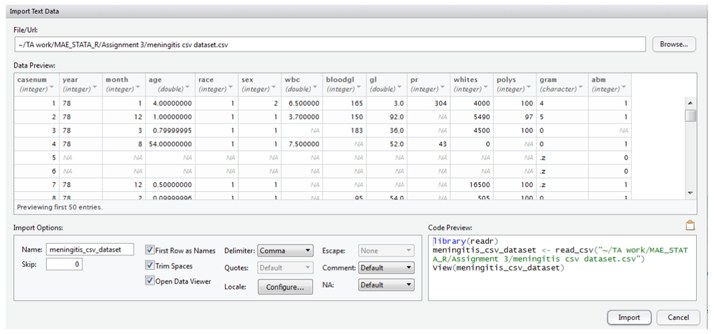

*Note: the code displayed varies from the one mentioned above. This is an example of the flexibility R provides the user with. There are multiple ways to do the same thing in R.*

The file has the variable names in the first row – you therefore you need to click on this box.

When you specify the required dataset, R will show you part of the dataset, as shown above. You can see that the first row of the file includes the names of the variables (this will generally be the case for most datasets that you will be working with), and you need to check the box First row as variable names.

```
Open the dataset using the read.csv command or File Import Menu. You can play around with opening the different
types of datasets.

What do you see in each of the windows when you open the dataset?
```

### Browsing your data

R Studio has a nice feature where everything is in one browser window, so you can browse your dataset and your code without having to switch between windows.

```r
#to view your dataset
View(meningitis)
```

Alternatively, you can also view your dataset by clicking on “meningitis” in on the top right panel in R studio browser (in the “Environment” panel), as shown below:

[figure not shown]

```
  How many variables are there? How many observations?
  What do you think that the NA values mean? (More on this later!)
```

### R help function

The `help()` function and `?` help operator in R provide access to the documentation pages for R functions, data sets, and other objects, both for packages in the standard R distribution and for contributed packages. Example: To access documentation for the standard *lm* (linear model) function, for example, enter the command `help(lm)` or `help("lm")`, or `?lm` in R console. Another way is shown below:

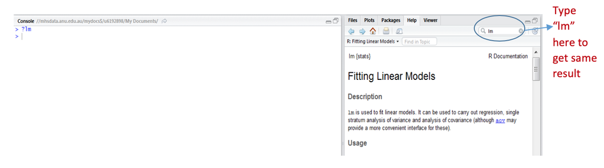

### R Commands vs Menu

So far we have used the menus to do what we want in R as well as typing the command directly into the console and then pressing the enter key (note that no commands will be read by R until you have hit enter). You may have noticed that when you use the menus, the commands actually appear in the console. This is very helpful as you can clearly see what commands you have undertaken, and can also enable you to copy and save commands into a file which you can later review or run again. Unlike Stata, R is more command driven than menu driven and the menu-driven methods allow for limited functions in R.

Almost everything in R is done through functions. A function is a piece of code written to carry out a specified task; it may accept arguments or parameters (or not) and it may return one or more values (or not!). The core of R is an interpreted computer language which allows branching and looping as well as modular programming using functions. R allows integration with the procedures written in the C, C++, .Net, Python or FORTRAN languages for efficiency.

**Table 2:** Some commonly used R commands

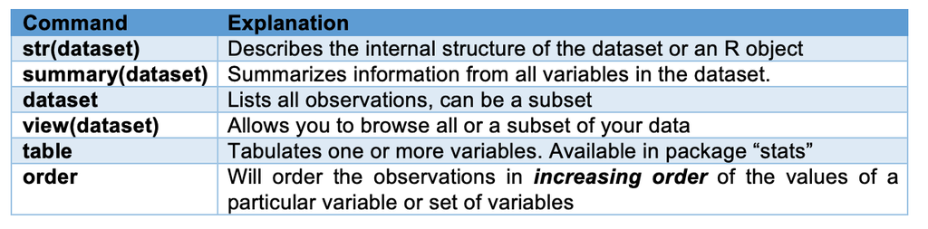

### The summary command

```
1. Type the word summary(dataset) in the console and press enter.
What has happened? How many variables are there? How many observations?

2. Type summary(sex) into the command bar.
How is this result different to the one above?
```

### Variable Types

Variables in R can contain numbers or strings (characters which can be letters or numbers, or sometimes other special characters). String variables can be up to 244 characters long. Numeric variables are stored either as integers (bytes, integers or longs) or floating point (float or double). The variable type is listed under the second column in the `str()` command output. You can check the length of the character variables using the `nchar()` command.

It is important to be familiar with different types of variables and the way they are stored in R. Some analyses require that data be stored as numeric rather than string variables. This means for example that sex is better stored as numbers (e.g. 0 or 1) rather than string variables (ie “female” or “male”).

While storing variable values as numbers is important for analysis, we need to be know what each of these values represent; for example if we code sex as 0 or 1, which value represents males and which females? We need to have a data dictionary, which “translates” the numeric values in to character labels. You can label the numeric values of a variable in R so that the words rather than the numeric values are displayed; the numeric values will be retained for analysis purposes. We will discuss this later.

```
Type dataset_name in the console and press enter. What does this show?
Type dataset_name$var1 then press enter. What does this show?
```

### Summarising and Describing Data

Tabulating data:

```r
#attach the dataset before analysis
attach(meningitis_csv_dataset)
table (sex)

# or you can avoid the 'attach(dataset)' by using the '$' operator to specify which dataset the variable comes from:
table(meningitis$sex)
```

```
What does the results window show? How many males and females are in the data set?
```

### Two-Way Table

```r
tab <- table(meningitis$sex, meningitis$abm)
tab

margin.table(tab, 1) # A frequencies (summed over B)
margin.table(tab, 2) # B frequencies (summed over A)

prop.table(tab) # Cell percentages

prop.table(tab,1) # Row percentages
```

```
We have previously generated the table of acute bacterial meningitis by sex, with row percentages (ie the percentage of males and females who had acute bacterial meningitis). Now use R commands to generate column percentage;
i.e. the % of those with and without acute bacterial meningitis who were female.
```

### The Summary Command

One method of obtaining descriptive statistics is to use the summary command and follow it with the `sapply( )` function with a specified summary statistic (e.g. SD).

```r
sapply(meningitis$wbc, sd, na.rm=TRUE)
```

Other possible functions used in sapply include mean, var, min, max, median, range, and quantile.

Alternatively, you can also use `describe()` command available in `library(psych)` - after first downloading the package under Packages tab > install, in the bottom right hand RStudio window.

```
What is the minimum, maximum, mean, standard deviation and median value for blood glucose?
```

```r
library(psych)
describe(meningitis$bloodgl)
```

### The order command

The `order` command allows you to arrange the observations in the dataset in increasing or decreasing order of a particular variable, or set of variables. For example you may want to sort the observations in order of patient id number

The default method of sorting is in ascending order. To sort in decreasing order a minus sign (ie “-“) must be placed in front of the variable to be sorted. To preserve the original dataset, we create two new datasets (m1) and (m2) where:

m1 is the dataset where we have sorted the original dataset in ascending order of variable “casenum”.

m2 is the dataset where we have sorted the original dataset in descending order of variable “casenum”.

You can confirm this by viewing both datasets, as shown below.

```r
m1 <- meningitis[order(meningitis$casenum),]
head(m1, n=10) # selects first 10 rows for you to view - observe the order of the variable "casenum"
```

```
##    casenum year month         age race sex wbc bloodgl gl  pr whites polys
## 1        1   78     1  4.00000000    1   2 6.5     165  3 304   4000   100
## 2        2   78    12  1.00000000    1   1 3.7     150 92  NA   5490    97
## 3        3   78     3  0.79999995    1   1  NA     183 36  NA   4500   100
## 4        4   78     8 54.00000000    1   1 7.5      NA 52  43      0    NA
## 5        5   NA    NA          NA   NA  NA  NA      NA NA  NA     NA    NA
## 6        6   NA    NA          NA   NA  NA  NA      NA NA  NA     NA    NA
## 7        7   78    12  0.50000000    1   1  NA      NA NA  NA  16500   100
## 8        8   78     2  0.09999996    1   1  NA      95 54  NA    505   100
## 9        9   NA    NA          NA   NA  NA  NA      NA NA  NA     NA    NA
## 10      10   78    12 11.00000000    2   2  NA      NA 35 175    700     1
##    gram abm
## 1     4   1
## 2     5   1
## 3     0  NA
## 4     0   1
## 5    .z   0
## 6    .z   0
## 7    .z   1
## 8     0   1
## 9    .z   0
## 10    0  NA
```

```r
m2 <- meningitis[order(-meningitis$casenum),]
head(m2, n=10)
```

```
##     casenum year month  age race sex       wbc bloodgl gl  pr whites polys
## 581     581   70     7 13.0    2   1 12.500000     122 35 176   8145    82
## 580     580   70     7  1.0    1   2 11.599999      NA 73  NA    240    50
## 579     579   70     8  8.0    1   1 15.099999     140 95  NA     69    88
## 578     578   70     7 23.0    1   1 10.599999      NA 84  32    242     4
## 577     577   70     7  2.0    1   2  4.900000      NA 85  18    100    90
## 576     576   70     7 14.0    1   2 12.099999     110 60  37    121    80
## 575     575   70     7  0.6    1   1 10.500000      NA NA  36     36     6
## 574     574   70    11 24.0    2   1  7.299999     116 67  NA     34    62
## 573     573   70     6 22.0    2   1 12.599999     143 54  NA   7900    93
## 572     572   72     7 25.0    2   1  8.000000     150 86  NA    193     1
##     gram abm
## 581    2   1
## 580    0  NA
## 579   .z   0
## 578   .z   0
## 577    0   1
## 576   .z   0
## 575   .z   0
## 574   .z   0
## 573    0  NA
## 572   .z   0
```

```
What has now happened to the observations?
```

Multiple variables can be used to sort the observations. For example, a dataset includes individuals with more than one record, such as baseline data and data for two follow-up visits, we could sort by patient and id and then visit number (or date). We can sort one (or more) variable in increasing order and another (or more) in decreasing order. When we list more than one variable for sorting, observations are sorted by the first variable and then for each value of the first variable, observations are ordered by the second variable, and so on. You can sort by any type of variable – continuous, categorical, and binary or string.

```
Sort the observations by increasing year of admission and then by increasing age, and look at the data. Now sort by increasing year of admission and decreasing age and see what has happened. Sort by CSF glucose within sex. How has R dealt with missing values?
```

Some procedures require that the data be sorted by particular variable/s. The menus will often undertake a data sort for many procedures requiring sorted data, however using R code / commands may still require you to sort the data before performing a particular procedure or operation; If that is the case R will give you an error message specifying that the data have not been sorted.

### To Repeat Commands by Groups.

R doesn’t use the if and by command as STATA to repeat commands across groups. It is done differently as shown below.

To produce the separate tables of acute bacterial meningitis for males and females, we can tabulate abm with sex as we did above:

```r
table(meningitis$abm, meningitis$sex)
```

```
##
##       1   2
##   0 118  85
##   1 113 104
```

```r
# to make it easier to interpret, we can add table labels:

table(abm=meningitis$abm,sex=meningitis$sex)
```

```
##    sex
## abm   1   2
##   0 118  85
##   1 113 104
```

```
Does acute bacterial meningitis appear to be higher for males or females? Does R account for missing values?
```

Table ignores missing values. To include NA as a category in counts, include the table option `exclude=NULL` if the variable is a vector. If the variable is a factor you have to create a new factor using `newfactor <- factor(oldfactor, exclude=NULL)`.

```r
summary(meningitis$wbc[meningitis$sex==1])
```

```
##    Min. 1st Qu.  Median    Mean 3rd Qu.    Max.    NA's
##    1.70    8.30   11.80   13.33   16.20   53.50     119
```

Note that we have to specify two equal signs: == not =. Double equal signs are always required for such commands. This is one of the syntax rules of R and the command won’t run if this is not specified correctly.

You can also use the above command to specify a range of values to be included in the analysis:

```r
table(meningitis$abm[meningitis$wbc>=5 & meningitis$wbc<=10])
```

```
##
##  0  1
## 94 32
```

```
What is the mean CSF protein for participants aged between 20 and 70?
What proportion of white females had acute bacterial meningitis?
```

```r
summary(meningitis$pr[meningitis$age>=20 & meningitis$age<=70])
```

```
##    Min. 1st Qu.  Median    Mean 3rd Qu.    Max.    NA's
##     1.0    53.0    96.0   207.4   209.8  1740.0     114
```

```r
t <- table(meningitis$sex, meningitis$abm, meningitis$race==2)
prop.table(t,1)*100
```

```
## , ,  = FALSE
##
##
##            0        1
##   1 30.13100 27.07424
##   2 26.59574 33.51064
##
## , ,  = TRUE
##
##
##            0        1
##   1 20.52402 22.27074
##   2 18.61702 21.27660
```

### The keep and drop commands

In R, its is easier to keep the variables than drop them. There is no keep command, but we can specify the variables you want to retain in the dataset. It is always better to create a new dataset with the fewer variables than modify the existing dataset.

There are 3 major ways to do this in R

##### Select variables v1, v2, v3

`myvars <- c("v1", "v2", "v3")`

`newdata <- mydata[myvars]`

##### Another method

`myvars <- paste("v", 1:3, sep="")`

`newdata <- mydata[myvars]gc`

##### Select 1st and 5th thru 10th variables

`newdata <- mydata[c(1,5:10)]`

Example: you can subset the meningitis dataset as:

```r
Meningitis1 <- meningitis[c(1:11,13:14)]
```

To drop or exclude variables, you can use the following syntax:

##### Exclude variables v1, v2, v3

`myvars <- names(mydata) %in% c("v1", "v2", "v3")`

`newdata <- mydata[!myvars]`

If we have a very large dataset and want to retain only a small number of variables then the keep statement would be more efficient.

##### To remove observations with particular characteristics

```r
newdata <- meningitis[ which(meningitis$age <20 ),]
```

#### Generating Graphs

Graphs are a very useful way of summarising and describing data, and enable you to look at the shape of the distribution. R has very good graphics packages including `ggplot2`.

##### Histograms

We will first generate a histogram for white blood count (WBC).

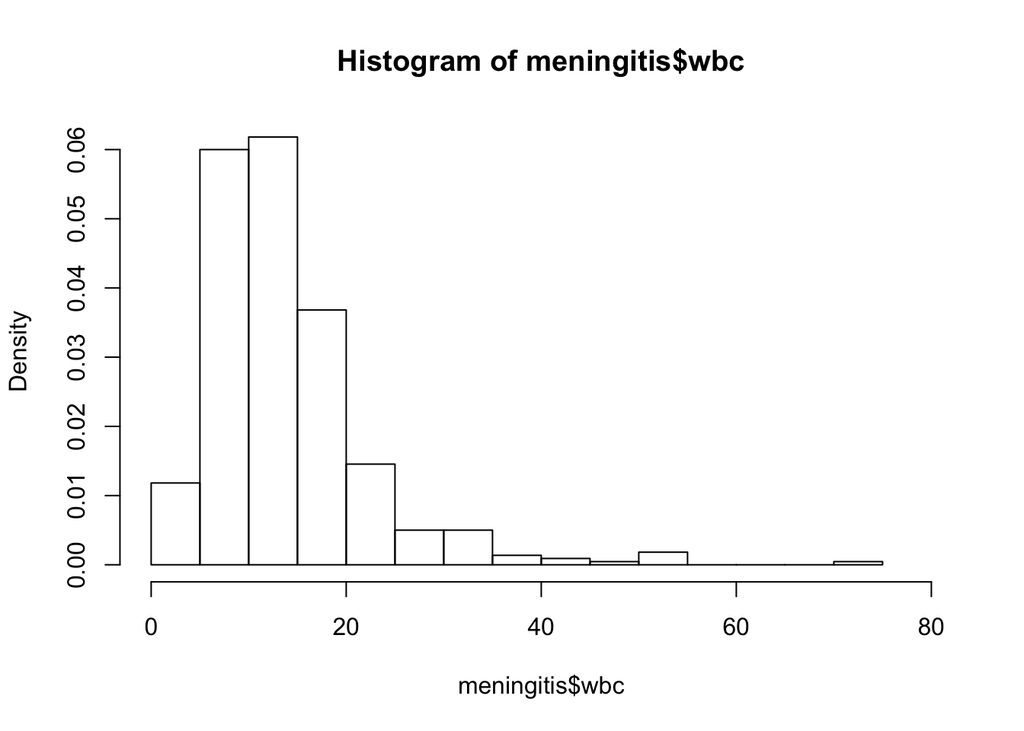

```r
# The below code generates a histogram
hist(meningitis$wbc, freq = FALSE, breaks = 17, xlim = c(0,80)) # freq FALSE will plot density on y-axis instead of frequency and xlim sets the range on the x axis to be from 0 to 80, with 17 breaks (bins)
```

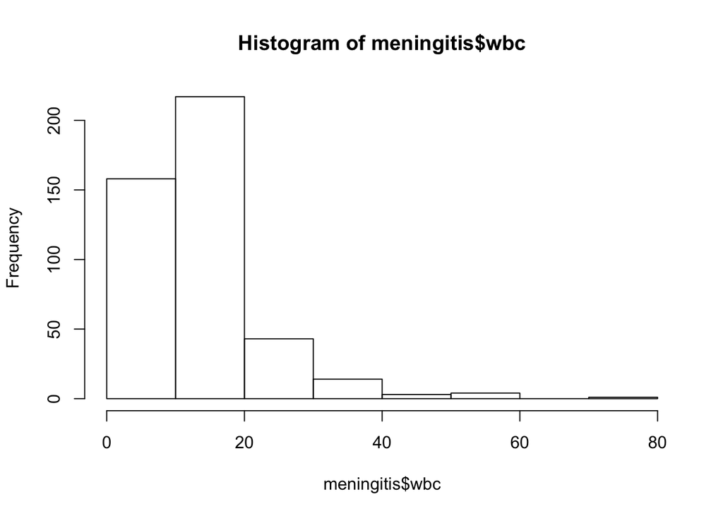

```
What do you think about the distribution for white blood count?

Generate a histogram for blood glucose. What do you think about the shape of the distribution? Regenerate the
histogram but add the breaks option and specify 20. What does this do?

Also note what is the default number of bins specified when we use the `hist()` command alone
```

```r
# The below code generates the same histogram but without the breaks specification and x-axis limitation
hist(meningitis$wbc)
```

If we want to see how close to a normal distribution our histogram is we can overlay a normal curve.

To do this, we first calculate mean and standard deviation for bloodgl.

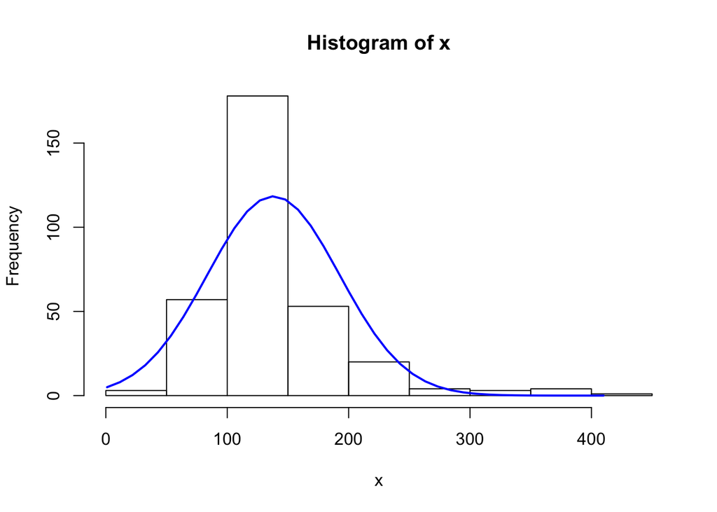

```
Generate a graph of CSF glucose with 25 bins and a normal curve overlay. What does this graph show? Does it look reasonable? What might you interpret from this graph?
```

```r
x <- na.omit(meningitis$bloodgl)
h <- hist(x)
xfit<-seq(min(x),max(x),length=40)
yfit<-dnorm(xfit,mean=mean(x),sd=sd(x))
yfit <- yfit*diff(h$mids[1:2])*length(x)
lines(xfit, yfit, col="blue", lwd=2)
```

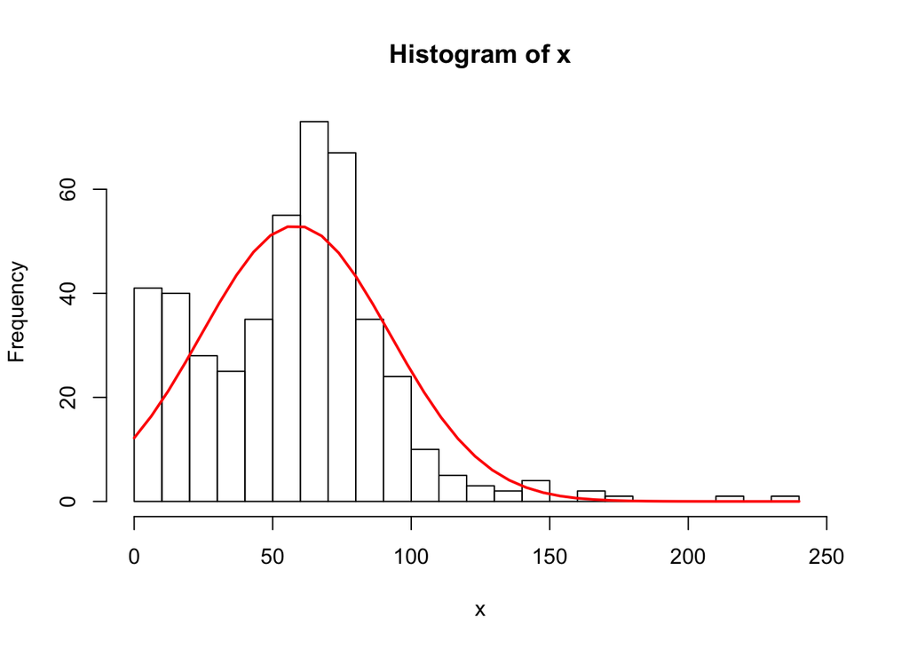

```
Using the command line rather than the graphics menu, generate a graph of CSF glucose with a normal curve overlay for: a) males only; b) for participants aged between 15 and 75.
```

```r
x <- na.omit(meningitis$gl)
h <- hist(x, breaks = 25, xlim = c(0,250))

xfit<-seq(min(x),max(x),length=40)
yfit<-dnorm(xfit,mean=mean(x),sd=sd(x))
yfit <- yfit*diff(h$mids[1:2])*length(x)
lines(xfit, yfit, col="red", lwd=2)
```

[figure not shown]

```r
#a)
x <- subset(meningitis, sex==2) # subsetting dataset by males only
x <- na.omit(meningitis$gl)
h <- hist(x, breaks = 25, xlim = c(0,250) , main = "Histogram of glucose CSF \n for males", xlab = " glucose CSF") # main heading and x-axis titles have been added here
xfit<-seq(min(x),max(x),length=40)
yfit<-dnorm(xfit,mean=mean(x),sd=sd(x))
yfit <- yfit*diff(h$mids[1:2])*length(x)
lines(xfit, yfit, col="blue", lwd=2)
```

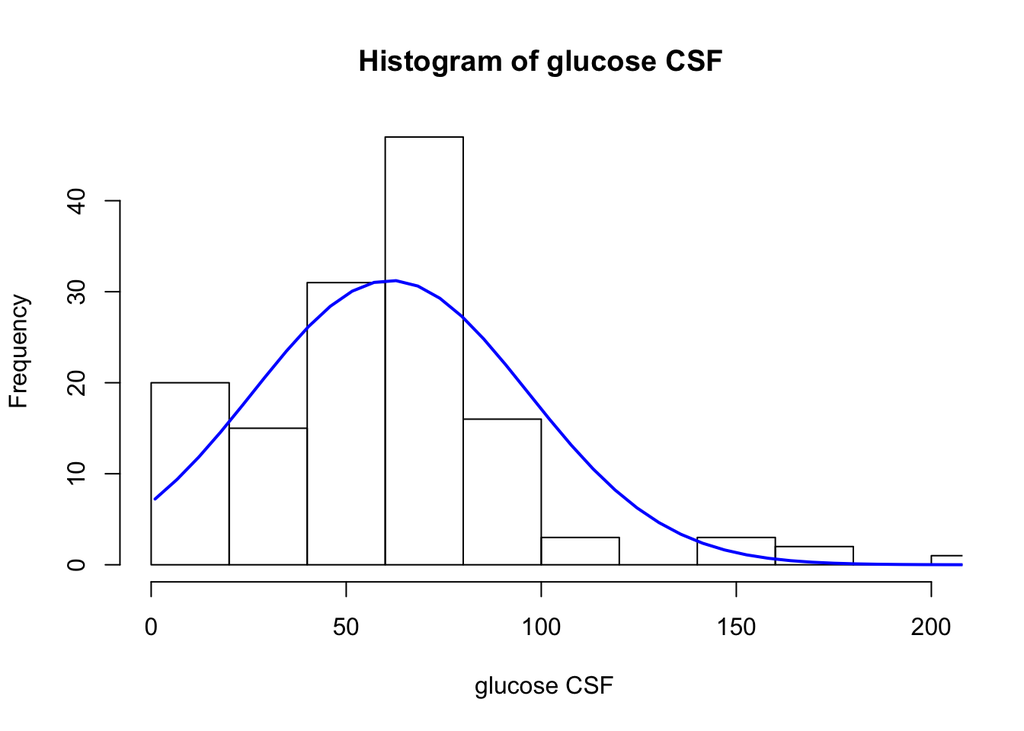

```r
#b)

x1 <- na.omit(meningitis$gl[meningitis$age >=15 & meningitis$age<=75])
h <- hist(x1, breaks = 11, xlim = c(0,200), main = "Histogram of glucose CSF", xlab = " glucose CSF")

xfit<-seq(min(x1),max(x1),length=40)
yfit<-dnorm(xfit,mean=mean(x1),sd=sd(x1))
yfit <- yfit*diff(h$mids[1:2])*length(x1)
lines(xfit, yfit, col="blue", lwd=2)
```

### Scatter plots

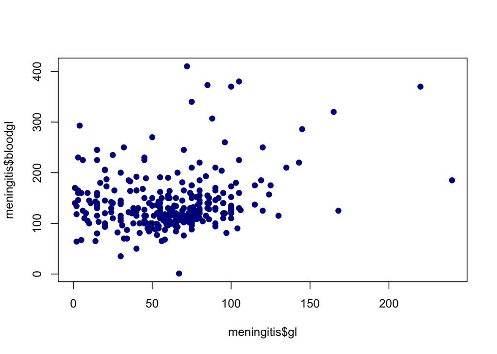

```r
#pch command will give sold circles to mark points in a graph
plot(meningitis$gl, meningitis$bloodgl, pch = 19, col = "darkblue")
```

There are a very large range of options in R for specifying the look of the graph, including titles, labelling and defining axes, the colour and shape of the markers (i.e. the points on the graph), legend specification and location, subsetting, putting multiple plots on the same graph, etc. An example of R code to produce a graph of CSF versus blood glucose, separately for males and females is shown below with the corresponding graph.

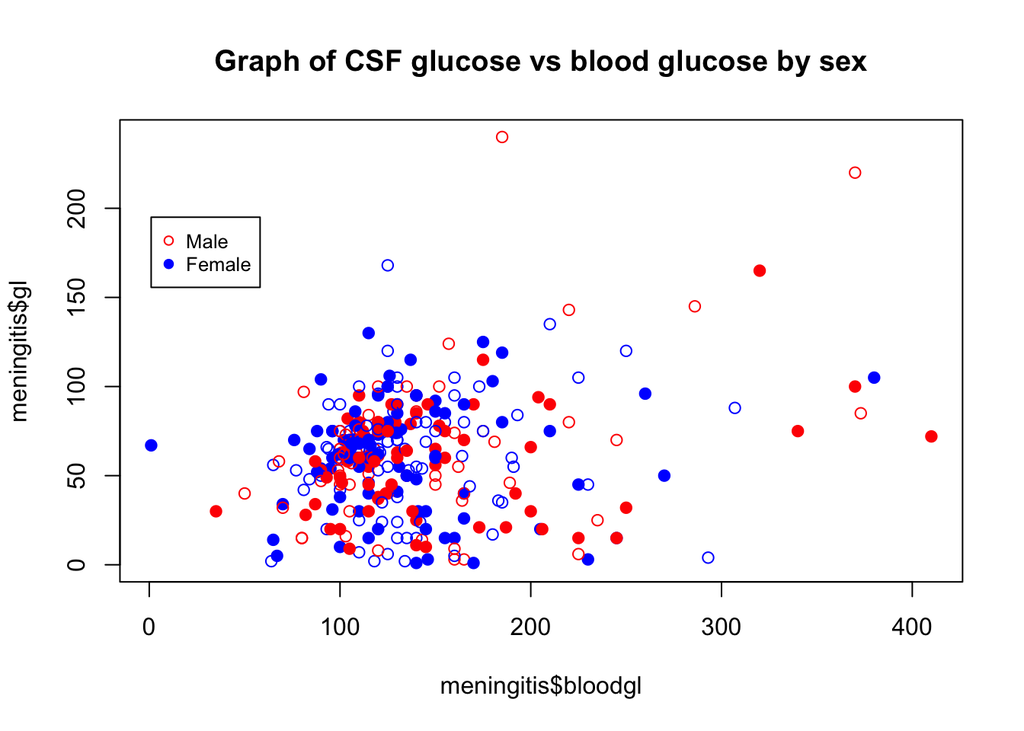

```
Play around with generation of scatter plots of white blood count versus total leukocytes separately for patients with and without acute bacterial meningitis. Try and change the colour and type of markers, axes, title and legends.
```

```r
plot(meningitis$bloodgl, meningitis$gl, pch = c(21, 19), col= c("blue", "red")[unclass(meningitis$sex)], main = "Graph of CSF glucose vs blood glucose by sex")

#Add legend
legend(1,195, legend = c("Male", "Female"), col = c("Red","Blue"), pch = c(21, 19), cex = 0.8)
```

### Saving results and commands

It is very important to retain a copy of your results so that you, or anyone can check this, and to be able to re-run your analysis at any time. In addition you will often want to, add to, repeat or revise your analyses. You do not want to have to type in your commands or re-do all of the menu analysis again, thus you also should save a copy of all of your commands.

#### Saving graphs

Graphs are not saved in the results window, or the log file, and need to be individually saved.

To do this click on Export and save as either Image or pdf. You can also copy the plot onto your clipboard.

[figure not shown]

This then opens up a black page, something like a Word document, which you can put all of your commands. This is a good strategy, especially when you first start using R. Alternatively, you can also open a new R script using Ctrl+ Shift+ N.

You can add comments on a line after a hashtag (#) as shown in the R script example below.

In computer programming, a comment is a programmer-readable explanation in the source code of a computer program. They are added with the purpose of making the source code easier to understand, and are generally ignored by compilers and interpreters.

The `setwd` command at the start of the file tells R to change your working directory to the one specified. This means that you don’t have to specify the directory every time you open or save a file.

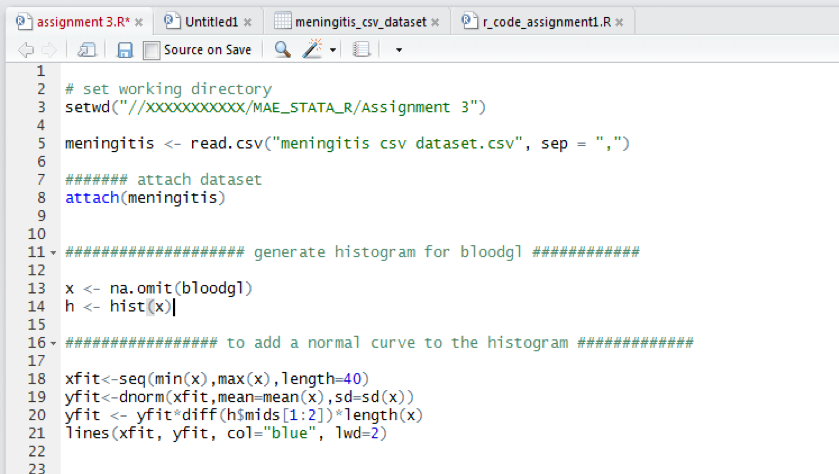

```
Have a play around with R, using both the icons and command line. Tabulate each of the variables individually;
e.g. year. Do all of the values seem reasonable? Are there any unusual or extreme values? Generate some two way
tables; e.g. race abm, and look at the relationship between these variables. See what different types of graphs
you can generate using the commands.
```

### Descriptive Statistics

This section describes how to generate confidence intervals and undertake hypothesis tests using R.

As for many types of analyses there is more than one command which provide the same/similar results. This section only focuses on how to undertake hypothesis tests in R, and does not consider the appropriateness of the test, nor assumptions checks.

#### Confidence Intervals for a Single Mean or Proportion

```
We want to obtain the 95% confidence interval for mean birthweight for a sample with the following features:
o   20 observations
o   Sample mean of 3159 grams
o   Sample standard deviation of 220 grams
```

Unlike Stata, we need to construct the 95% CI for mean. The 95% confidence interval for the population mean can be expressed as:

$$\overline{X}\pm1.96\sigma/\sqrt{n}$$

```r
## Descriptive statistics
# 95% CI for mean
n <- 20
xbar <- 3159
sd <- 220

# calculate standard error
se <- sd/(sqrt(n))
E <- 1.96*se
# or alternatively, E <- qnorm(0.975)*se
ci<- xbar + c (-E, E)
ci
```

```
## [1] 3062.581 3255.419
```

The 95% CI is (3063, 3255). We are 95% sure that the true (population) mean lies between 3063 and 3255; if we were to undertake this study 100 times, 95 of the CIs would include the true mean.

```r
## Descriptive statistics
# 99% CI for mean
n <- 20
xbar <- 3159
sd <- 220

# calculate standard error
se <- sd/(sqrt(n))
E <- qnorm(0.995)*se
ci<- xbar + c (-E, E)
ci
```

```
## [1] 3032.286 3285.714
```

The 99% CI is (3032, 3286). What is the interpretation of this interval?

```
Calculate the 95% confidence interval for mean birthweight for babies of mothers:
a) who were vaccine; and
b) who were not vaccinated
```

[^1]: Spanos A, Harrell FE, Durack DT. Differential diagnosis of acute meningitis: An analysis of the predictive value of initial observations. JAMA, 1989; 262: 2700-2707
[^2]: Donegan K, King B and Bryan P. Safety of pertussis vaccination in pregnant women in UK: observational study. BMJ 2014;349:g4219 doi: 10.1136/bmj.g4219 (Published 11 July 2014